# KwaThunzi runoff time-series simulation

## Data import and preparation

Import the runoff dataset 1960-2018 of the Umkomazi gauging station (ID: U1H005) available at the [Department of Water Affairs](http://www.dwa.gov.za/Hydrology/). The runoff Q is in unit [m³/s].

```r
runoff <- read_table2("../data/U1H005_daily.txt",
                      col_types = cols(DATE = col_integer()),
                      skip = 10)
head(runoff, 3)
```

| DATE | Q | QUAL |
| --- | --- | --- |
| 19600901 | 2.608 | 1 |
| 19600902 | 2.583 | 1 |
| 19600903 | 2.559 | 1 |

Clean the data and set column formats. The quality code indicating the validity of each observation is available here Create seperate columns for ‘year’ and ‘doy’(day-of-year) for each observation.

```r
runoff[is.na(runoff$QUAL),2] <- NA # remove Quality measures that shifted in the Q column
runoff <- ts.format(runoff, format="%Y%m%d", cols=c(1,2)) # set date format
runoff$year <- as.integer(substr(runoff$Date, 1,4)) # derive year
runoff$doy <- as.numeric(strftime(runoff$Date, format = "%j"))  # derive day-of-year
runoff <- na.omit(runoff) # delete empty fields
head(runoff, 3)
```

| Date | Q | QUAL | year | doy |
| --- | --- | --- | --- | --- |
| 1960-09-01 | 2.608 | 1 | 1960 | 245 |
| 1960-09-02 | 2.583 | 1 | 1960 | 246 |
| 1960-09-03 | 2.559 | 1 | 1960 | 247 |

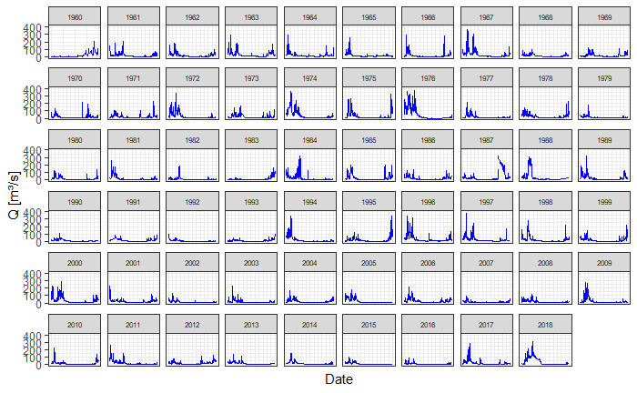

## Runoff transformation and aggregation

Transform discharge by base 10 logarithm.

```r
runoff$Qlog <- log10(runoff$Q)  # calculate Log base 10 of runoff
runoff <- runoff[!(runoff$Qlog=='-Inf'),] # delete -Inf
head(runoff,3)
```

| Date | Q | QUAL | year | doy | Qlog |
| --- | --- | --- | --- | --- | --- |
| 1960-09-01 | 2.608 | 1 | 1960 | 245 | 0.4163076 |
| 1960-09-02 | 2.583 | 1 | 1960 | 246 | 0.4121244 |
| 1960-09-03 | 2.559 | 1 | 1960 | 247 | 0.4080703 |

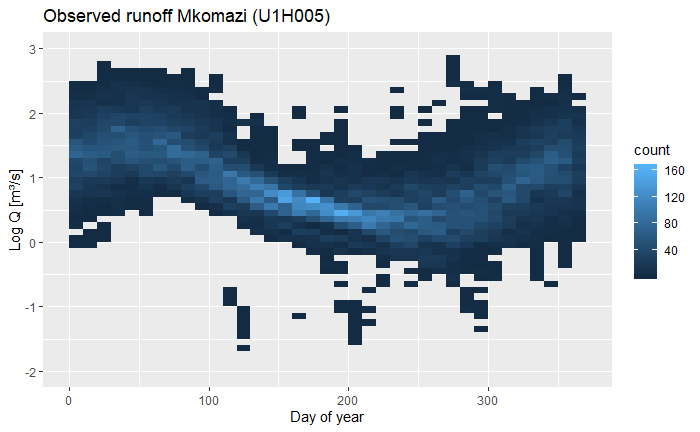

Calculate daily mean and standard deviation for each day-of-year.

```r
#Create empty data frame
runoff_aggregates <- data.frame()

#aggregate mean runoff per day
runoff_aggregates <- aggregate(runoff, by=list(runoff$doy), FUN=mean)[,c('doy','Qlog')]

#aggregate mean runoff per day
runoff_aggregates$sd <- aggregate(runoff, list(runoff$doy), FUN=sd)[,c('Qlog')]

names(runoff_aggregates) <- c('doy','mean','sd')
```

## Runoff simulation

Simulate expected runoff of each day of any timeseries. Create randomized values, based on the observed annual discharge distribution, which was derived from the time series 1960-2018. The random values are estimated from mean and standard deviation of each daily runoff.

```r
set.seed(2020)
number_of_years <- 500 # years to be simulated
runoff_pred <- data.frame()

for(i in runoff_aggregates$doy){
  x <- rnorm(number_of_years, mean=runoff_aggregates$mean[i], sd=runoff_aggregates$sd[i])
  pred <- data.frame(cbind(seq(1,500,1), # year
                         rep(i,500),   # doy
                         x))           # predicted values
  runoff_pred <- rbind(runoff_pred, pred)
}
names(runoff_pred) <- c('year','doy','Qlog')
```

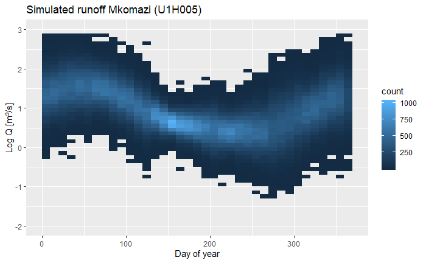

Backtransformation of the logarithmic runoffs to regular Q [m³/s]

```r
runoff_pred$Q <- 10^runoff_pred$Qlog
```

## Calculation of area specific runoff and export to file

Calculate area specific runoff (q) after Baumgartner and Liebscher (1996) and Casper and Bormann (2016) using
$$\begin{equation}q = \frac{Q}{A}\end{equation}$$
with Q = runoff at the gauging station and A = catchment area

```r
catchment_area <- 1744 * 1000000 # area in [m²]
runoff_pred$q <- runoff_pred$Q/catchment_area
```

Order rows by year and day-of-year

```r
runoff_pred <- runoff_pred[order(runoff_pred$year, runoff_pred$doy),]
head(runoff_pred, 6)
```

|  | year | doy | Qlog | Q | q |
| --- | --- | --- | --- | --- | --- |
| 1 | 1 | 1 | 1.4499444 | 28.180219 | 1.615838e-08 |
| 501 | 1 | 2 | 1.8259061 | 66.973978 | 3.840251e-08 |
| 1001 | 1 | 3 | 1.3288005 | 21.320654 | 1.222515e-08 |
| 1501 | 1 | 4 | 1.9601689 | 91.236559 | 5.231454e-08 |
| 2001 | 1 | 5 | 0.8988826 | 7.922871 | 4.542931e-09 |
| 2501 | 1 | 6 | 1.5452669 | 35.096750 | 2.012428e-08 |

Export data to a structured file with the two columns ‘year’ and ‘q’, which is ready to use with the gully model

```r
out <- runoff_pred[,c("year", "q")]
out$q <- format(out$q, scientific = FALSE) # change to decimals
write.table(out, "../output/S_150_lts.txt", sep="\t", row.names=F, col.names=F, quote=F)
```

## References

BAUMGARTNER, A. & LIEBSCHER, H. J. 1996. Lehrbuch der Hydrologie, Band 1: Allgemeine Hydologie, Quantitative Hydrologie, Stuttgart, Germany, Schweizerbarth. CASPER, M. & BORMANN, H. 2016. Abfluss im Gewässersystem. In: FÖHRER, N., BORMANN, H., MIEGEL, K., CASPER, M., BRONSTERT, A., SCHUMANN, A. & WEILER, M. (eds.) Hydrologie. Bern, Switzerland: Haupt.